# Matplotlib

HakminLee

2022-02-27

본 자료는 연세대학교 DA 대학원에서 **김정은 교수님**께서 진행하신 **컴퓨터 프로그래밍** 과목의 수업 내용을 참고하여 제작

## Matplotlib 개요

Python에서는 `matplotlib`이라는 라이브러리를 통해 시각화를 할 수 있다.  
시각화란 데이터를 그래프로 표현하는 것을 의미한다.

먼저 가장 간단한 꺾은선, 막대, 점 그래프를 그려본다.

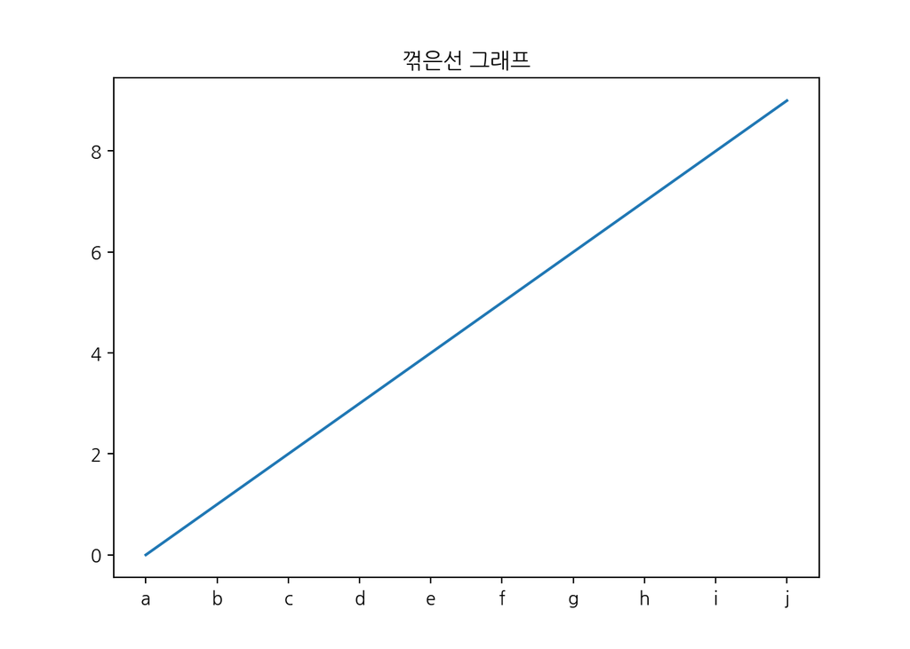

```python
import matplotlib.pyplot as plt
plt.rcParams['axes.unicode_minus'] = False

data = [i for i in range(10)]
index = list('abcdefghij')

plt.figure()
plt.title('꺾은선 그래프')
plt.plot(index, data)
plt.show()
```

```python
plt.figure()
plt.title('막대 그래프')
plt.bar(index, data)
```

```
## <BarContainer object of 10 artists>
```

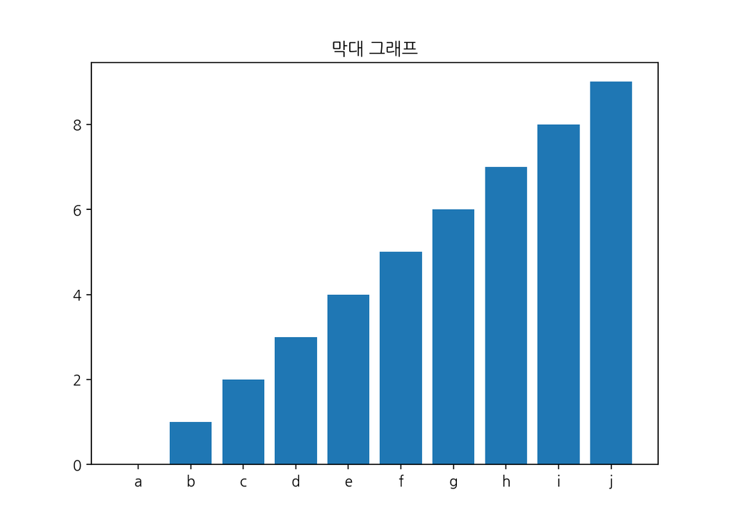

```python
plt.show()
```

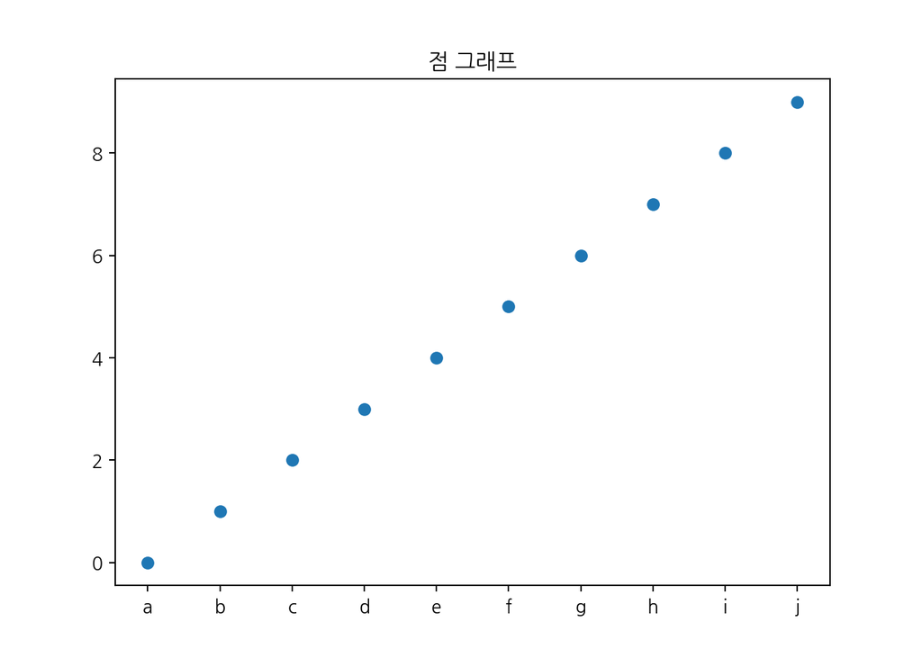

```python
plt.figure()
plt.title('점 그래프')
plt.scatter(index, data)
plt.show()
```

이번엔 세 가지 그래프를 한 화면에 배치 할 수 있도록 그려보자. 먼저 영역을 분할해본다.

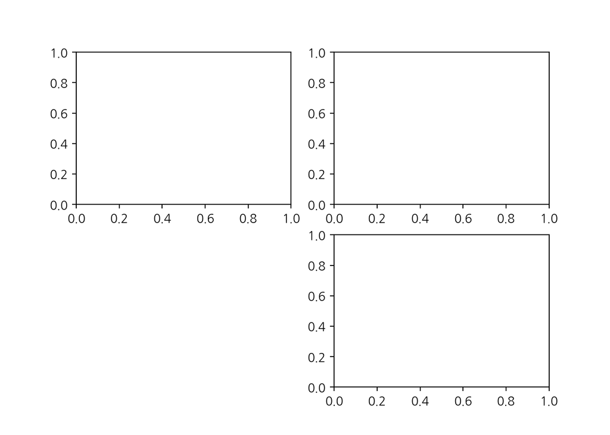

```python
fig = plt.figure() #그래프의 바탕(도화지)이 되는 figure 객체 생성
ax1 = fig.add_subplot(2,2,1) #2x2 구간 중 1번째 index에 subplot 생성
ax2 = fig.add_subplot(2,2,2) #2x2 구간 중 2번째 index에 subplot 생성
ax4 = fig.add_subplot(2,2,4) #2x2 구간 중 4번째 index에 subplot 생성
plt.show()
```

각각 분할한 영역에 그래프를 추가해보자.

```python
fig = plt.figure() #그래프의 바탕(도화지)이 되는 figure 객체 생성
ax1 = fig.add_subplot(2,2,1) #2x2 구간 중 1번째 index에 subplot 생성
ax2 = fig.add_subplot(2,2,2) #2x2 구간 중 2번째 index에 subplot 생성
ax4 = fig.add_subplot(2,2,4) #2x2 구간 중 4번째 index에 subplot 생성
ax1.plot(index, data)
ax2.bar(index, data)
```

```
## <BarContainer object of 10 artists>
```

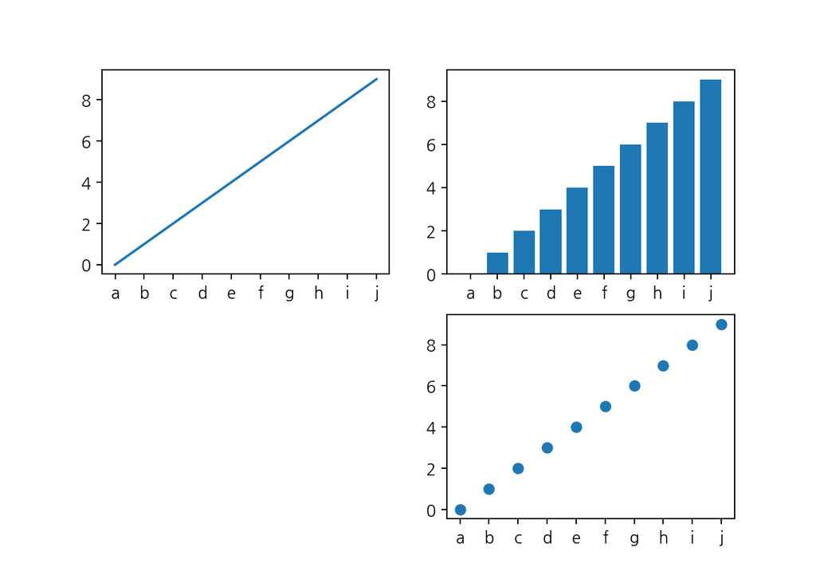

```python
ax4.scatter(index, data)
plt.show()
```

## 상태 기반 인터페이스 vs 객체 지향 인터페이스

matplotlib은 서로 다른 두 가지의 인터페이스를 제공한다. 두 방법은 혼용이 가능하다.

### 상태기반 인터페이스 (함수명령문형)

위의 개요에서 그래프를 그렸던 방식이 **상태기반 인터페이스**이다. **상태기반 인터페이스**는 명시적으로 그래프 객체를 선언하지 않고 묵시적으로 현재까지의 상태를 추적 및 관리하고 저장한다. 일일이 하나하나 지정해 줄 필요가 없다는 점에서 간편하나 복잡한 그래프를 만들 때 제약이 따른다. 그래프를 그릴 때 `plt.함수명(인수)` 형태의 함수 명령문을 사용하므로 **함수명령문형 인터페이스**라고도 한다.

### 객체지향 인터페이스

**객체지향 인터페이스**는 명시적으로 그래프 객체를 선언하여 변수에 할당하고, 해당 객체의 메소드를 통해 그래프를 그린다. Python 문법과 호출하는 방식이 유사하므로 파이썬 이용자에게 좀 더 직관적인 방법이다. 객체를 일일이 지정해줘야하는 번거로움이 있지만 복잡한 그래프를 그릴 때 헷갈림이 덜하고 유용하다. `객체.메소드(매개변수)`의 형태로 사용한다.

아래는 **객체지향 인터페이스**로 그래프를 그린 예시이다.

```python
fig, ax = plt.subplots(nrows = 2, ncols = 2,
                        sharex = True, sharey= True, figsize = (6,6)) #subplot 객체 선언 (ax)
ax[0][0].plot(index, data)
ax[0][1].bar(index, data)
```

```
## <BarContainer object of 10 artists>
```

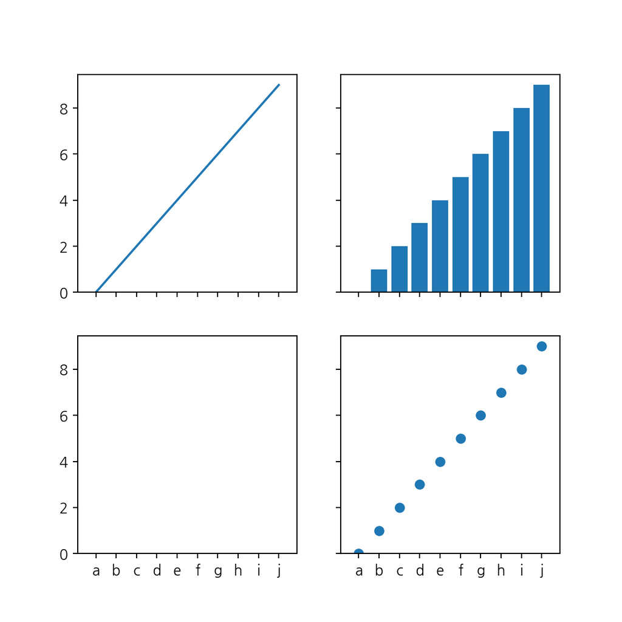

```python
ax[1][1].scatter(index, data)
plt.show()
```

## 색상, 선스타일, 마커

먼저 하나의 서브 플롯에 여러개의 꺾은선 그래프를 그리고 색상, 선 스타일, 마커를 추가해보자.

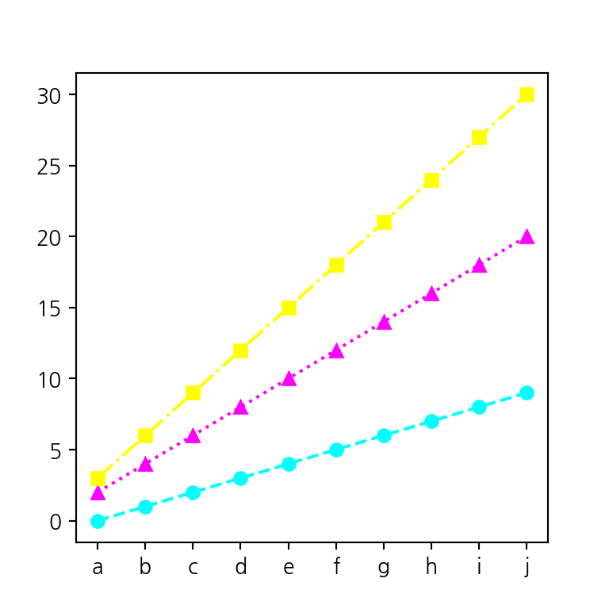

```python
fig, ax = plt.subplots(figsize = (4,4))
index = list('abcdefghij')
value1 = [i for i in range(10)]
value2 = [i for i in range(2, 22, 2)]
value3 = [i for i in range(3, 33, 3)]

ax.plot(index, value1, color = 'cyan', linestyle = '--', marker = 'o')
ax.plot(index, value2, color = 'magenta', linestyle = ':', marker = '^')
ax.plot(index, value3, color = 'yellow', linestyle = '-.', marker = 's')
plt.show()
```

다음과 같이 축약형을 쓰거나 스타일 사전을 만들어서 간편하게 전달하는 것도 가능하다.

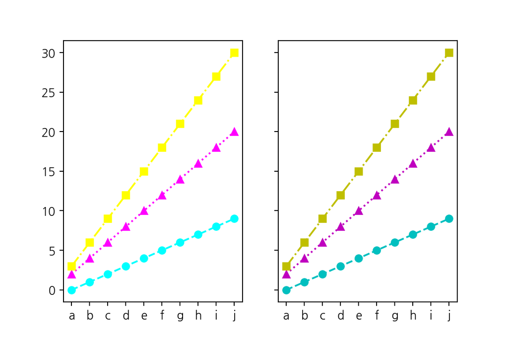

```python
fig, ax = plt.subplots(1, 2, figsize = (6,4), sharey=True)
style1 = {'color':'cyan', 'linestyle':'--', 'marker':'o'}
style2 = {'color':'magenta', 'linestyle':':', 'marker':'^'}
style3 = {'color':'yellow', 'linestyle':'-.', 'marker':'s'}

#사전 사용
ax[0].plot(index, value1, **style1)
ax[0].plot(index, value2, **style2)
ax[0].plot(index, value3, **style3)

#축약형
ax[1].plot(index, value1, 'co--')
ax[1].plot(index, value2, 'm^:')
ax[1].plot(index, value3, 'ys-.')
plt.show()
```

## 범례(legend), 제목

범례와 제목을 추가해보자

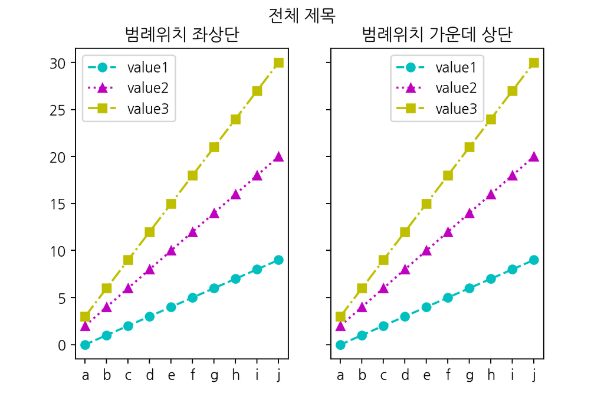

```python
fig, ax = plt.subplots(1, 2, figsize = (6,4), sharey=True)

ax[0].plot(index, value1, 'co--', label = 'value1')
ax[0].plot(index, value2, 'm^:', label = 'value2')
ax[0].plot(index, value3, 'ys-.', label = 'value3')
ax[0].set_title('범례위치 좌상단')
ax[0].legend(loc='best')

ax[1].plot(index, value1, 'co--', label = 'value1')
ax[1].plot(index, value2, 'm^:', label = 'value2')
ax[1].plot(index, value3, 'ys-.', label = 'value3')
ax[1].set_title('범례위치 가운데 상단')
ax[1].legend(loc='upper center') #범례 위치 조정

fig.suptitle('전체 제목')
plt.show()
```

## x,y 축

x, y축에 제목을 부여하고 눈금별 항목명을 지정해보자

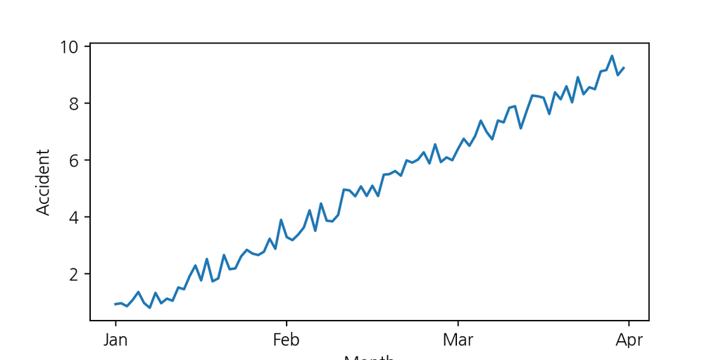

```python
import random
value4 = [base*0.1 + random.random() for base in range(90)]

fig, ax = plt.subplots(1,1,figsize = (6,3))
ax.plot(value4)

ax.set_xticks([0,30,60,90]) #눈금폭 지정
ax.set_xticklabels(['Jan', 'Feb', 'Mar', 'Apr']) #눈금마다 표시할 레이블명

ax.set_xlabel('Month') #x축 제목
ax.set_ylabel('Accident') #y축 제목

plt.show()
```

단위가 크게 다른 두 개의 데이터를 한 그래프에 표시할 때 y축을 두개 사용할 수 있다.

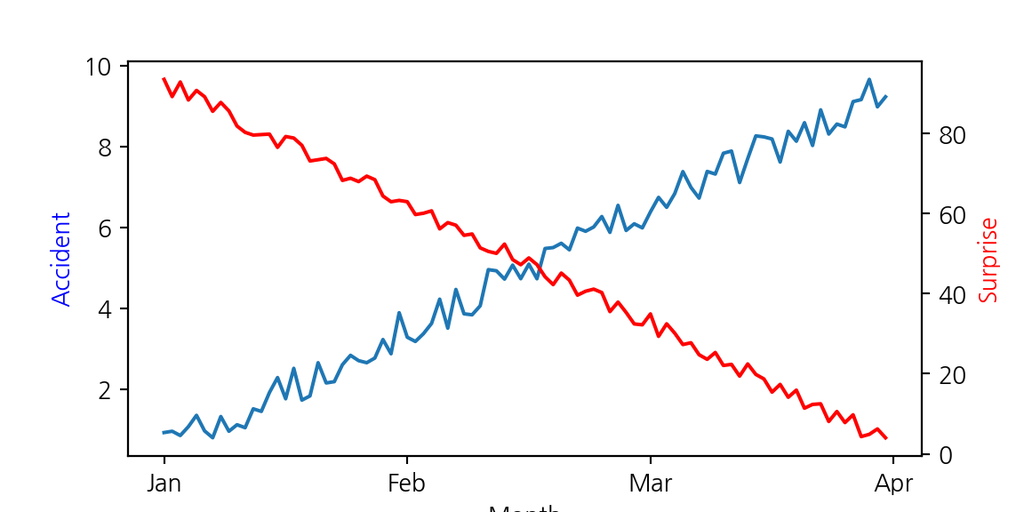

```python
value5 = [base + random.random()*5 for base in range(90,0,-1)]

fig, ax = plt.subplots(1,1,figsize = (6,3))
ax.plot(value4)

ax.set_xticks([0,30,60,90]) #눈금폭 지정
ax.set_xticklabels(['Jan', 'Feb', 'Mar', 'Apr']) #눈금마다 표시할 레이블명

ax.set_xlabel('Month') #x축 제목
ax.set_ylabel('Accident', color='blue') #y축 제목

ax2 = ax.twinx() #제 2의 축 생성
ax2.plot(value5, color = 'red')
ax2.set_ylabel('Surprise', color='red')

plt.show()
```

눈금의 척도를 log scale로 변경하는 것도 가능하다.

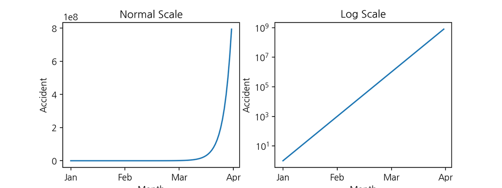

```python
value6 = [10 ** (base*0.1) for base in range(90)]
fig, ax = plt.subplots(1, 2, figsize = (8,3))

for axe in ax.flat:
    axe.plot(value6)
    axe.set_xticks([0, 30, 60, 90])
    axe.set_xticklabels(['Jan', 'Feb', 'Mar', 'Apr'])
    axe.set_xlabel('Month')
    axe.set_ylabel('Accident')

ax[1].set_yscale('log')
ax[0].set_title('Normal Scale')
ax[1].set_title('Log Scale')

plt.show()
```

## 주석 달기 (Annotate)

그래프에서 강조하고 싶은 부분에 주석을 다는 것도 가능하다.

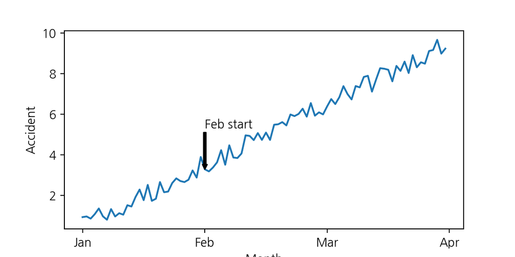

```python
fig, ax = plt.subplots(1,1,figsize = (6,3))
ax.plot(value4)

ax.set_xticks([0,30,60,90]) #눈금폭 지정
ax.set_xticklabels(['Jan', 'Feb', 'Mar', 'Apr']) #눈금마다 표시할 레이블명

ax.set_xlabel('Month') #x축 제목
ax.set_ylabel('Accident') #y축 제목

ax.annotate('Feb start', #출력할 문자열
            xy = (30, value4[30]), #화살촉 위치
            xytext = (30, value4[30]+2.5), #문자열 위치
            arrowprops = dict(facecolor = 'black', headwidth = 4,
                              width = 2, headlength = 4), #화살표 속성
            horizontalalignment = 'left', # 문자열 좌우정렬
            verticalalignment = 'top' # 문자열 상하정렬
            )

plt.show()
```

## 서브플롯 간 간격

서브플롯 간의 간격을 조정할 수 있다.

```python
#정규분포를 따르는 100개의 난수를 4묶음 생성
normal_dist = [[random.gauss(0, 1) for _ in range(100)] for _ in range(4)]

fig, ax = plt.subplots(2,2, figsize = (6,6), sharex = True, sharey = True)

for axe, ndist in zip(ax.flat, normal_dist):
    axe.hist(ndist)

#서브플롯 간 여백을 제거
```

```
## (array([ 3.,  8., 16., 12., 17., 14., 15.,  8.,  4.,  3.]), array([-1.99027474, -1.56559298, -1.14091123, -0.71622947, -0.29154771,
##         0.13313404,  0.5578158 ,  0.98249755,  1.40717931,  1.83186107,
##         2.25654282]), <BarContainer object of 10 artists>)
## (array([ 3.,  2.,  0., 16., 20., 18., 20., 11.,  7.,  3.]), array([-3.05150799, -2.50771081, -1.96391363, -1.42011645, -0.87631927,
##        -0.33252209,  0.21127509,  0.75507226,  1.29886944,  1.84266662,
##         2.3864638 ]), <BarContainer object of 10 artists>)
## (array([ 3.,  2.,  7., 16., 20., 24., 11.,  9.,  6.,  2.]), array([-2.626961  , -2.10818291, -1.58940482, -1.07062673, -0.55184864,
##        -0.03307055,  0.48570754,  1.00448563,  1.52326372,  2.04204181,
##         2.5608199 ]), <BarContainer object of 10 artists>)
## (array([ 8.,  8., 22., 17., 19., 15.,  4.,  3.,  2.,  2.]), array([-1.74907603, -1.31003351, -0.870991  , -0.43194848,  0.00709403,
##         0.44613655,  0.88517906,  1.32422157,  1.76326409,  2.2023066 ,
##         2.64134912]), <BarContainer object of 10 artists>)
```

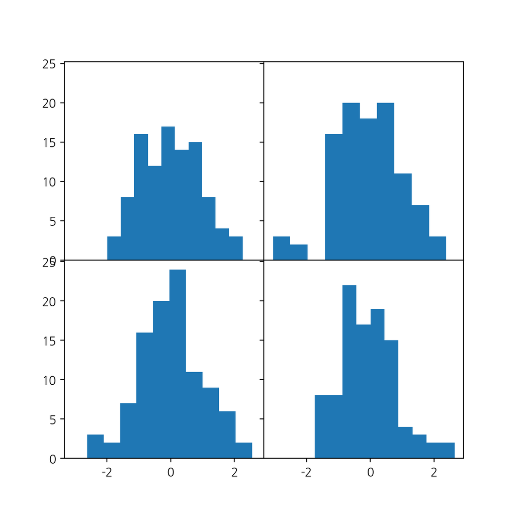

```python
plt.subplots_adjust(wspace = 0, hspace = 0)
plt.show()
```

## 막대 그래프

도시별 과일 소비량을 막대 그래프로 나타내보자

```python
Seoul = [800, 600, 900]
Busan = [900, 500, 870]
Fruit = ['grape', 'orange', 'apple']

fig, ax = plt.subplots(1,3, figsize=(10, 3))

#stack bar chart
ax[0].bar(Fruit, Seoul, label = 'Seoul')
```

```
## <BarContainer object of 3 artists>
```

```python
ax[0].bar(Fruit, Busan, label = 'Busan')
```

```
## <BarContainer object of 3 artists>
```

```python
ax[0].set_title('Stacked Bar')
ax[0].set_ylabel('Fruit Sales')
ax[0].legend(loc = 'lower center')

#grouped bar chart
width = 0.35
x0 = [x for x in range(len(Fruit))]
x1 = [x - width/2 for x in range(len(Fruit))]
x2 = [x + width/2 for x in range(len(Fruit))]

ax[1].bar(x1, Seoul, width, label = 'Seoul')
```

```
## <BarContainer object of 3 artists>
```

```python
ax[1].bar(x2, Busan, width, label = 'Busan')
```

```
## <BarContainer object of 3 artists>
```

```python
ax[1].set_title('Grouped Bar')
ax[1].set_xticks(x0)
ax[1].set_xticklabels(Fruit)

# Horizontal Bar
extended_label = [city + '_' + fr for city in ['Seoul', 'Busan'] for fr in Fruit]

ax[2].barh(extended_label, Seoul + Busan)
```

```
## <BarContainer object of 6 artists>
```

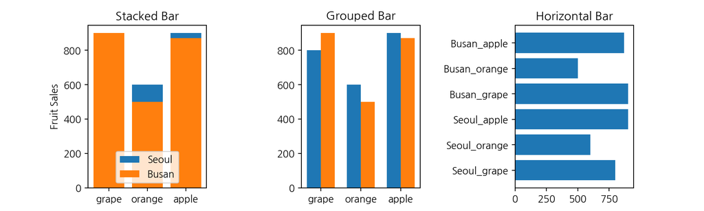

```python
ax[2].set_title('Horizontal Bar')
plt.subplots_adjust(hspace= 0.3, wspace = 0.8)
plt.show()
```

## 꺾은선 그래프

꺾은선 그래프는 시간의 흐름에 따른 변화 비교에 유용하다. 연도별 도시의 전력 소비 변화량을 꺾은선 그래프로 나타내자

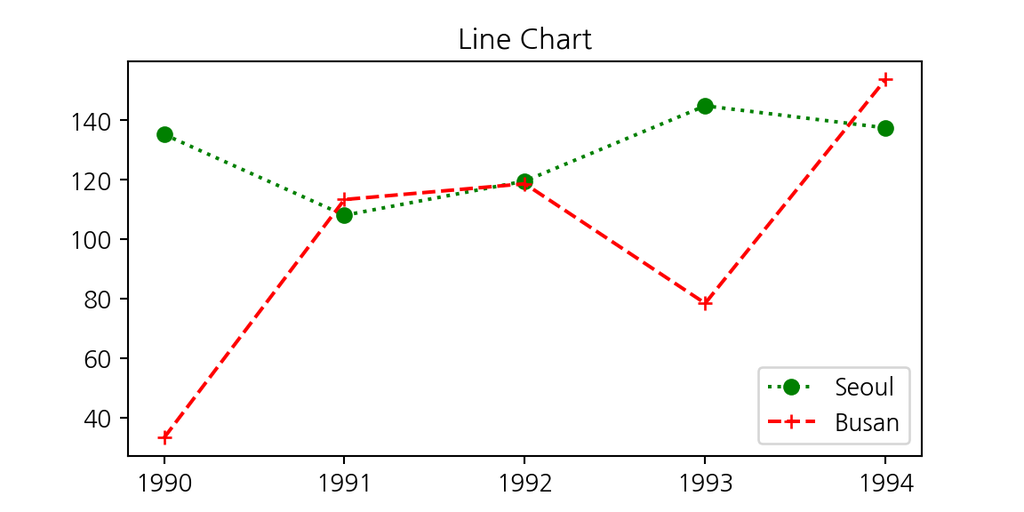

```python
Seoul = [135.2, 108.0, 119.5, 144.8, 137.4]
Busan = [33.2, 113.3, 118.6, 78.4, 153.7]
year = [1990, 1991, 1992, 1993, 1994]

fig, ax = plt.subplots(figsize=(6,3))

ax.plot(year, Seoul, label = 'Seoul', color = 'Green', marker = 'o', linestyle = ':')
ax.plot(year, Busan, label = 'Busan', color = 'Red', marker = '+', linestyle = '--')
ax.legend(loc = 'lower right')
ax.set_title('Line Chart')
ax.set_xticks(year)

plt.show()
```

## 히스토그램

히스토그램은 데이터의 분포를 살펴보는데 유용하다. 예를 들어 히스토그램을 그려봤을 때 양봉 분포가 나타난다면 서로 다른 두 개의 분포가 혼재되어 있다고 예상할 수 있다.  
아래의 예시는 영어를 모국어로 쓰는 학생 집단과 그렇지 않은 학생 집단의 영어 점수 분포이다.

```python
random.seed = 42
#영어가 모국어가 아닌 학생 200명의 영어 점수 (평균 72, 편차 8)
eng = [random.gauss(72, 8) for _ in range(200)]
eng = [i if i < 100 else 100 for i in eng]
eng = [i if i > 0 else 0 for i in eng]

#영어가 모국어인 학생 100명의 영어 점수 (평균 92, 편차 4)
eng2 = [random.gauss(92, 4) for _ in range(100)]
eng2 = [i if i < 100 else 100 for i in eng2]
eng2 = [i if i > 0 else 0 for i in eng2]

tot = eng + eng2

fig, ax = plt.subplots(figsize = (6, 4))
ax.hist(tot, bins=20)
```

```
## (array([ 1.,  1.,  2.,  2.,  6., 11., 15., 21., 32., 30., 28., 18., 17.,
##         7., 14., 18., 22., 24., 18., 13.]), array([ 46.20780139,  48.89741132,  51.58702125,  54.27663118,
##         56.96624111,  59.65585105,  62.34546098,  65.03507091,
##         67.72468084,  70.41429077,  73.1039007 ,  75.79351063,
##         78.48312056,  81.17273049,  83.86234042,  86.55195035,
##         89.24156028,  91.93117021,  94.62078014,  97.31039007,
##        100.        ]), <BarContainer object of 20 artists>)
```

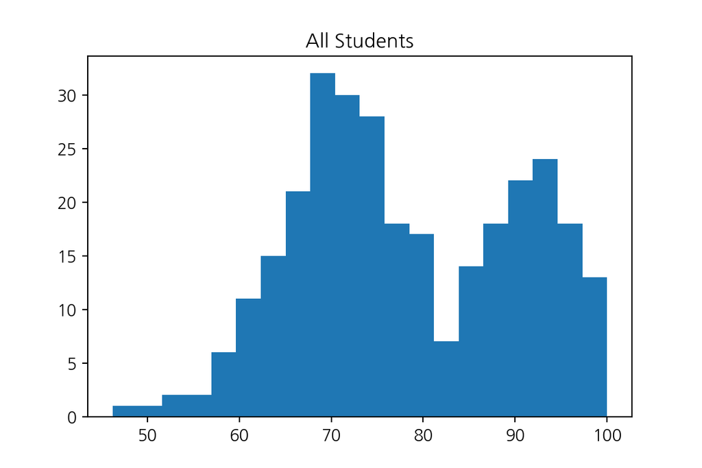

```python
ax.set_title('All Students')
plt.show()
```

위 분포를 분리해서 히스토그램으로 나타내면 명확하게 두 집단이 나타남을 확인할 수 있다.

```python
fig, ax = plt.subplots(1, 2, figsize = (10,4), sharex= True)
ax[0].set_title('Not English Mothertongue')
ax[0].hist(eng, bins=20)
```

```
## (array([ 1.,  1.,  0.,  2.,  3.,  4.,  8.,  9., 13., 20., 25., 28., 19.,
##        20., 14., 14.,  5.,  8.,  4.,  2.]), array([46.20780139, 48.36950471, 50.53120802, 52.69291133, 54.85461465,
##        57.01631796, 59.17802128, 61.33972459, 63.5014279 , 65.66313122,
##        67.82483453, 69.98653784, 72.14824116, 74.30994447, 76.47164779,
##        78.6333511 , 80.79505441, 82.95675773, 85.11846104, 87.28016435,
##        89.44186767]), <BarContainer object of 20 artists>)
```

```python
ax[1].set_title('English Mothertongue')
ax[1].hist(eng2, bins=20)
```

```
## (array([ 1.,  0.,  0.,  2.,  0.,  6.,  5.,  5.,  7.,  8.,  7.,  5.,  7.,
##        13.,  9.,  6.,  6.,  5.,  5.,  3.]), array([ 81.07800335,  82.02410318,  82.97020301,  83.91630284,
##         84.86240268,  85.80850251,  86.75460234,  87.70070217,
##         88.64680201,  89.59290184,  90.53900167,  91.48510151,
##         92.43120134,  93.37730117,  94.323401  ,  95.26950084,
##         96.21560067,  97.1617005 ,  98.10780033,  99.05390017,
##        100.        ]), <BarContainer object of 20 artists>)
```

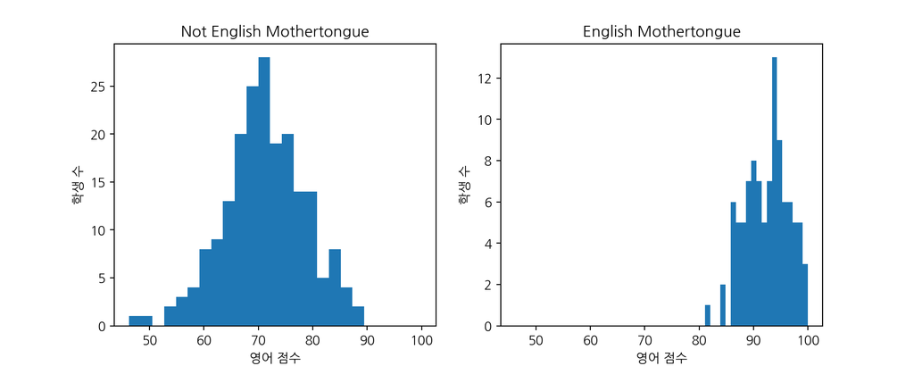

```python
for axe in ax.flat:
  axe.set_xlabel('영어 점수')
  axe.set_ylabel('학생 수')
plt.show()
```

## 박스플롯

여러 집단 간의 분포를 비교하기 위해 박스플롯을 그릴 수 있다. 앞에서 봤던 영어 모국어 그룹과 영어 외국어 그룹 간의 영어 점수 분포를 박스플롯으로 표현해보자.

```python
fig, ax = plt.subplots(figsize = (4, 4))

ax.boxplot([eng, eng2])
```

[output not shown]

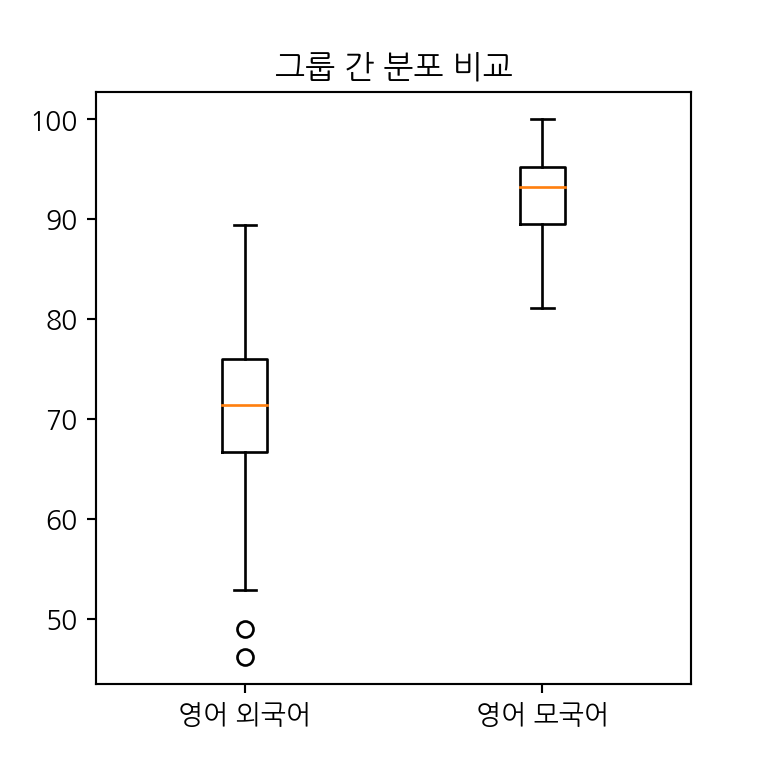

```python
ax.set_xticklabels(['영어 외국어', '영어 모국어'])
ax.set_title('그룹 간 분포 비교')

plt.show()
```

## 산포도 (scatter plot)

산포도는 변수간 관계를 관찰하기 위해 사용한다.

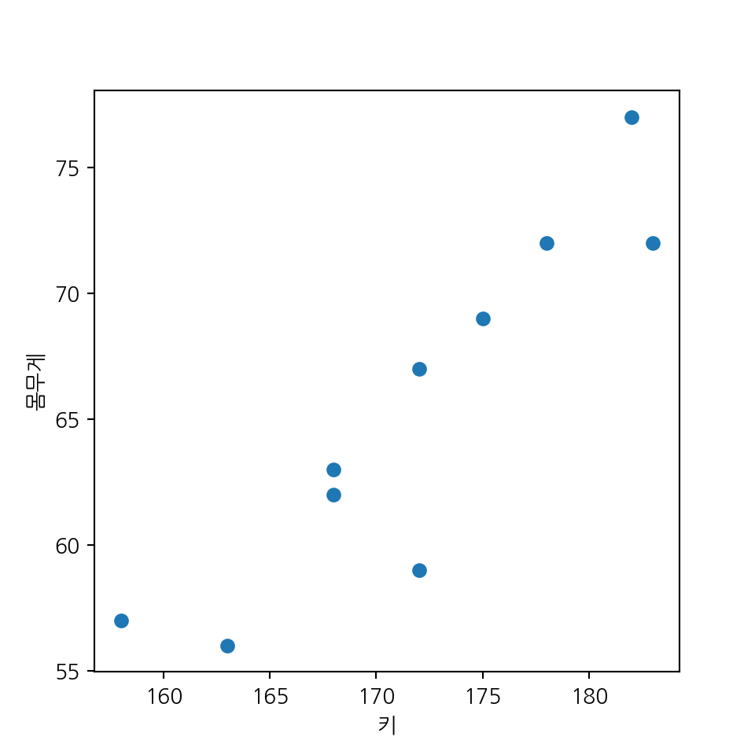

```python
size = [(168, 63), (172, 67), (183, 72), (158, 57), (175, 69),
        (172, 59), (178, 72), (182, 77), (168, 62), (163, 56)]

height = [h for h,w in size]
weight = [w for h,w in size]

fig, ax = plt.subplots(figsize = (5, 5))
ax.scatter(height, weight)

ax.set_xlabel('키')
ax.set_ylabel('몸무게')

plt.show()
```